# Untitled

Shaya Engelman

2024-03-06

1. Let X1, X2, . . . , Xn be n mutually independent random variables, each of which is uniformly distributed on the integers from 1 to k. Let Y denote the minimum of the Xi’s. Find the distribution of Y .

Y is the minimum of X. Let x be the smallest number. The probability that Y is greater than or equal to x is multiplying the probability of each X event together. P(X1) * P(X2) * . . . P(Xn). Each probability is written as $(k - x + 1)/k$. When mutiplying them all together we get $(k - x + 1)^n/k^n$. Since we were told that $Xi$ is uniformly distributed we are looking at 1 - the probability that Y is greater than x,
$$1 - (k - x + 1)^n/k^n$$
This is the CDF of Y. The PDF is the derivative of the CDF.
$$f(x)
= n(k - x)^{n-1}/k^n$$

We can visualize the distribution with the below plot:

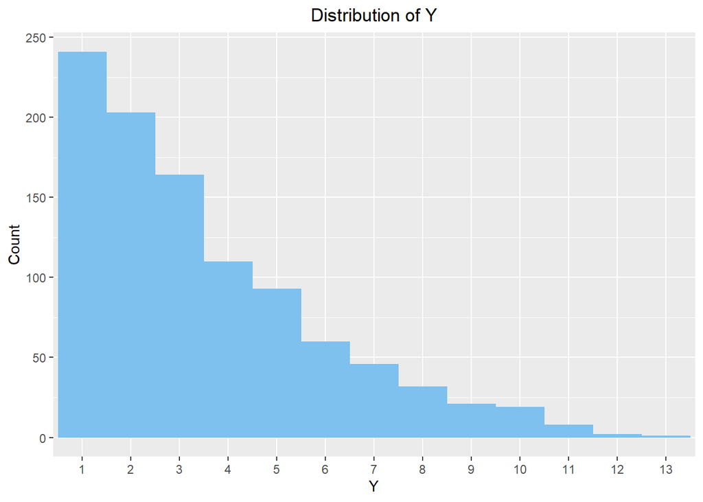

```r
set.seed(1125)
n <- 1000
k <- 20
Y <- c()
for (i in 1:n){
  Xn <- sample(1:k, 5)
  Y <- c(Y, min(Xn))
}
ggplot(data.frame(table(Y)), aes(Y, Freq)) +
  geom_bar(stat = "identity", fill = "skyblue2", width = 1) +
  ylab("Count") +
  ggtitle("Distribution of Y") +
  theme(plot.title = element_text(hjust = 0.5))
```

2. Your organization owns a copier (future lawyers, etc.) or MRI (future doctors). This machine has a manufacturer’s expected lifetime of 10 years. This means that we expect one failure every ten years. (Include the probability statements and R Code for each part.).

1. What is the probability that the machine will fail after 8 years?. Provide also the expected value and standard deviation. Model as a geometric. (Hint: the probability is equivalent to not failing during the first 8 years..)

$$P(X=x) = (1-p)^{x-1} \cdot
p$$

```r
p <- 1/10
k <- 8

geom_prob <- 1 - (1 - p)^(k - 1) * p

expected_value <- 1 / p
standard_deviation <- sqrt((1 - p) / p^2)

cat("Geometric Probability:", geom_prob, "\n")
```

```
## Geometric Probability: 0.9521703
```

```r
cat("Expected value: ", expected_value, "\n")
```

```
## Expected value:  10
```

```r
cat("Standard Deviation: ", standard_deviation, "\n")
```

```
## Standard Deviation:  9.486833
```

2. What is the probability that the machine will fail after 8 years?. Provide also the expected value and standard deviation. Model as an exponential.

$$f(x; \lambda) = \lambda \cdot
e^{-\lambda x}$$

```r
lambda <- 0.1

exp_prob <- exp(-lambda * 8)

expected_value <- 1 / lambda
standard_deviation <- 1 / lambda

cat("Exponential Probability:", exp_prob, "\n")
```

```
## Exponential Probability: 0.449329
```

```r
cat("Expected value: ", expected_value, "\n")
```

```
## Expected value:  10
```

```r
cat("Standard Deviation: ", standard_deviation, "\n")
```

```
## Standard Deviation:  10
```

3. What is the probability that the machine will fail after 8 years?. Provide also the expected value and standard deviation. Model as a binomial. (Hint: 0 success in 8 years)

$$P(X = k) = \binom{n}{k} \cdot p^k \cdot
(1-p)^{n-k}$$

```r
n <- 8
p <- 0.1
k <- 0

binom_prob <- dbinom(k, n, p)

expected_value <- n * p
standard_deviation <- sqrt(n * p * (1 - p))

cat("Binomial Probability:", binom_prob, "\n")
```

```
## Binomial Probability: 0.4304672
```

```r
cat("Expected value: ", expected_value, "\n")
```

```
## Expected value:  0.8
```

```r
cat("Standard Deviation: ", standard_deviation, "\n")
```

```
## Standard Deviation:  0.8485281
```

4. What is the probability that the machine will fail after 8 years?. Provide also the expected value and standard deviation. Model as a Poisson.

$$P(X=k) = \frac{e^{-\lambda} \cdot
\lambda^k}{k!}$$

```r
lambda <- 0.8
k <- 0
pois_prob <- dpois(k, lambda)

lambda <- 1
expected_value <- lambda
standard_deviation <- sqrt(lambda)
cat("Poisson Probability:", pois_prob, "\n")
```

```
## Poisson Probability: 0.449329
```

```r
cat("Expected value: ", expected_value, "\n")
```

```
## Expected value:  1
```

```r
cat("Standard Deviation: ", standard_deviation, "\n")
```

```
## Standard Deviation:  1
```